# Preliminary genotyping QC

[output not shown]

## Agenda

- Load in description of available samples and assess what combinations of cohorts make sense
- Main steps for DNA methylation QC (see tutorial that Giulia sent)
- See what Magda did for combining samples from her paper (if the information is there)
- Apply appropriate QC pipeline steps to data
- Devise and run a “check” that the pipeline is doing something reasonable
  - Ask victor about this one
  - Check publication/QC pipeline for this as well

## Main DNA methylation QC steps

1. Gathering samples
   1. navigating and loading robinson lab’s file structure
   2. reading in idat and converting to beta values (2 commands in minfi)
2. Checking samples are what they say they are
   1. Check sex based on XY and XIST probe
   2. Check identity to ensure not array replicates
3. cell type estimation and related
4. Normalization

### 1.2 Raw data from Genome Studio

This section of code is used to construct a MethylSet from the type of output file created for Genome Studio. This code was written originally by Magda and has been modified by Victor. **NOTE: The redGEORawFile() function from Minfi also works really well, although it drops the SNP probes**. See: https://rdrr.io/bioc/minfi/man/readGEORawFile.html

#### 1.2.1 Get meth/unmeth matrices

Often, raw DNAme data on GEO or from Genome Studio is stored in the form of a dataframe with columns containing the methylated and unmethylated (or A/B or Red/Green) signal intensities. This can be parsed into a methylset, which is a minfi object built to contain these intensity values.

According to *Page 48* of the the [Genome Studio Methylation Module v1.8 User Guide](https://support.illumina.com/content/dam/illumina-support/documents/documentation/software_documentation/genomestudio/genomestudio-2011-1/genomestudio-methylation-v1-8-user-guide-11319130-b.pdf), *Methylated == Signal B == Green*

This data is often stored seperately as a supplementary file in GEO.

```r
# Magda's code

# read in the 1st 5 lines of the file
methy_data1 <- fread("/scratch/st-dennisjk-1/wcasazza/delahaye_QC/placenta_regulatory_landscape/RootStudyConsentSet_phs001717.PlacentalRegulation.v1.p1.c1.HMB-IRB-PUB-COL-MDS/GenotypeFiles/phg001182.v1.PlacentalRegulation.genotype-original-submission.divers_arrays.c1.HMB-IRB-PUB-COL-MDS.update/corrected_run44_NICHD_ctrl-bkg.txt")
methy_data2 <- fread("/scratch/st-dennisjk-1/wcasazza/delahaye_QC/placenta_regulatory_landscape/RootStudyConsentSet_phs001717.PlacentalRegulation.v1.p1.c1.HMB-IRB-PUB-COL-MDS/GenotypeFiles/phg001182.v1.PlacentalRegulation.genotype-original-submission.divers_arrays.c1.HMB-IRB-PUB-COL-MDS.update/corrected_run47_NICHD_ctrl_bkg.txt")[,-c(1)]
methy_data <- cbind(methy_data1,methy_data2)
run_44 <- unique(gsub("\\..*","",colnames(methy_data1)))
run_47 <- unique(gsub("\\..*","",colnames(methy_data2)))
metadata$batch <- ifelse(metadata$SUBJECT_ID %in% run_44, "run_44",ifelse(metadata$SUBJECT_ID %in% run_47,"run_47",NA))
colnames(methy_data) # figure out naming convention, should contain columns for methylated, unmethylated, and detection p values for all samples.
methy_data <- as.data.frame(methy_data)
# separate the methy_data data into 3 matrices: Detection.Pval, Unmethylated.Signal and Methylated.Signal (these can sometimes be named A/B/Green/Red)
rownames(methy_data) <- methy_data[,1] # first column contains probe IDs, make  rownames
methy_data <- methy_data[,-1]

Detection.1 <- methy_data[,grep(".Detection Pval", colnames(methy_data))]
colnames(Detection.1) <- gsub(".Detection Pval", "", colnames(Detection.1))
colnames(Detection.1) # 36

unmeth.1 <- methy_data[,grep(".Signal_A", colnames(methy_data))]
colnames(unmeth.1) <- gsub(".Signal_A", "", colnames(unmeth.1))
colnames(unmeth.1) # 36

meth.1 <- methy_data[,grep(".Signal_B", colnames(methy_data))]
colnames(meth.1) <- gsub(".Signal_B", "", colnames(meth.1))
colnames(meth.1) # 36

# sanity check that everything matches
identical(rownames(meth.1), rownames(unmeth.1))
identical(rownames(meth.1), rownames(Detection.1))

identical(colnames(meth.1), colnames(unmeth.1))
identical(colnames(meth.1), colnames(Detection.1))
```

#### 1.2.2 Construct MethylSet

```r
mset <- new("MethylSet",
        SummarizedExperiment(assays = SimpleList(Meth = as.matrix(meth.1),
                                                 Unmeth = as.matrix(unmeth.1))),
        annotation = c(array="IlluminaHumanMethylation450k",annotation="ilmn12.hg19"),
        preprocessMethod = c(rg.norm='Raw (no normalization or bg correction)',
                            minfi='1.24.0', manifest='0.4.0'))
# pData(mset) <- DataFrame(pData1) # add in pData
mset # this object should be 485577 rows long (if it doesn't contain SNP probes will be 485512)
```

```r
# code from Victor

# this code checks that the methylset has been constructed from the correct meth/unmeth columns by pulling the beta values and making sure that the beta value density distribution makes sense. the hypomethylated peak should be bigger if the mset has been constructed properly.

rgset <- mapToGenome(ratioConvert(mset))

# plot density, if the meth/unmeth intensities are flipped, then the hypermethylated peak will be bigger than the hypomethylated peak.
betas <- as.data.frame(getBeta(mset))
head(betas)
```

|  | 8366 | 8367 | 8368 | 8369 | 8370 | 8371 | 8372 | 8374 | 8394 | 8395 | 8396 | 8397 | 8399 | 8400 | 8401 | 8403 | 8405 | 8407 | 8408 | 8409 | 8410 | 8418 | 8419 | 8420 | 8421 | 8422 | 8423 | 8424 | 8425 | … |
| --- | --- | --- | --- | --- | --- | --- | --- | --- | --- | --- | --- | --- | --- | --- | --- | --- | --- | --- | --- | --- | --- | --- | --- | --- | --- | --- | --- | --- | --- | --- |
| cg00000029 | 0.0920000 | 0.0676750 | 0.0672005 | 0.09373336 | 0.05568829 | 0.0625711 | 0.09042985 | 0.08638563 | 0.04070328 | 0.05429914 | 0.05599704 | 0.07601687 | 0.09672939 | 0.0864970 | 0.1025812 | 0.09155485 | 0.1819613 | 0.07018481 | 0.08460659 | 0.05493102 | 0.06577705 | 0.09841933 | 0.05940909 | 0.07650961 | 0.08228731 | 0.08557845 | 0.08525588 | 0.06240197 | 0.08234694 | … |
| cg00000108 | 0.9343107 | 0.9485234 | 0.9446833 | 0.93125646 | 0.96276293 | 0.9540150 | 0.93959387 | 0.94133919 | 0.91933503 | 0.94674686 | 0.92603062 | 0.92935561 | 0.92510392 | 0.9146341 | 0.9469285 | 0.95125812 | 0.9491194 | 0.94362044 | 0.94429910 | 0.95964392 | 0.95026760 | 0.92977351 | 0.93832169 | 0.91561877 | 0.92170176 | 0.95879842 | 0.94227543 | 0.95036836 | 0.90831557 | … |
| cg00000109 | 0.9077280 | 0.9222116 | 0.9259958 | 0.94416562 | 0.93136612 | 0.8942781 | 0.89979989 | 0.92278439 | 0.91003555 | 0.88831000 | 0.92040083 | 0.87677569 | 0.89301587 | 0.8867066 | 0.8934984 | 0.88940014 | 0.7615243 | 0.92964103 | 0.89890038 | 0.84987549 | 0.78801306 | 0.85787183 | 0.89557010 | 0.86977850 | 0.92468222 | 0.88251975 | 0.88825128 | 0.88019967 | 0.94631902 | … |
| cg00000165 | 0.6084620 | 0.5699678 | 0.6674884 | 0.71474441 | 0.47279673 | 0.4953851 | 0.68249334 | 0.59959202 | 0.52180937 | 0.57423795 | 0.61179361 | 0.55390060 | 0.44729551 | 0.6553964 | 0.6350458 | 0.46625354 | 0.4597429 | 0.57257143 | 0.64459142 | 0.70274141 | 0.57977566 | 0.63969389 | 0.61795457 | 0.60609583 | 0.61620072 | 0.59309072 | 0.50371725 | 0.52665094 | 0.55941428 | … |
| cg00000236 | 0.8406097 | 0.8069340 | 0.8632291 | 0.82059421 | 0.84651231 | 0.8089816 | 0.81807524 | 0.81117231 | 0.83646209 | 0.83722683 | 0.83059813 | 0.83032491 | 0.78307003 | 0.7723395 | 0.8292020 | 0.80997958 | 0.7723188 | 0.80931264 | 0.84336283 | 0.79848012 | 0.75804430 | 0.83757682 | 0.82852253 | 0.81432393 | 0.84135977 | 0.78341860 | 0.81321128 | 0.83703969 | 0.78998050 | … |
| cg00000289 | 0.8284258 | 0.8631693 | 0.8707665 | 0.82030402 | 0.87166614 | 0.7763371 | 0.87641068 | 0.85940836 | 0.69225806 | 0.51881586 | 0.75715174 | 0.69035692 | 0.74216028 | 0.8336628 | 0.8210391 | 0.85730594 | 0.5549555 | 0.78406828 | 0.79183163 | 0.61616515 | 0.42048656 | 0.71001088 | 0.71446004 | 0.78922872 | 0.77960526 | 0.74197689 | 0.76628749 | 0.75716353 | 0.79145196 | … |

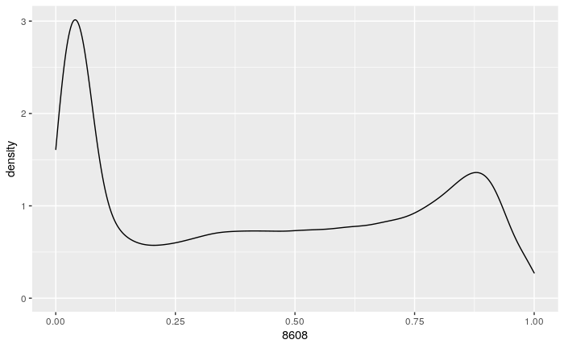

```r
ggplot(betas, aes(x= `8608`)) +
  geom_density()
```

Starting with all samples, check for confounding wrt sex associations for batch, cross-platform issues, and disease:

```r
betas <- getBeta(mset)
dim(betas) # 485512     36

head(colnames(betas)) # sentrix ID and position concatenated
colnames(betas) <- make.unique(metadata$sample)

head(colnames(mset))
colnames(mset) <-make.unique(metadata$sample)
```

### Checking sex

```r
# extract the probes from the Illumina manifest corresponding to the X/Y chromosome
data(IlluminaHumanMethylation450kanno.ilmn12.hg19)
data(Locations)
sexProbeIDs <- Locations[which(Locations$chr == "chrY" | Locations$chr == "chrX"),]

# pull XY probes
betasXY <- betas[which(rownames(betas) %in% rownames(sexProbeIDs)),] # 11648
dim(betasXY) # 11648 by 46 good
```

```
[1] 11648   302
```

```r
sum(is.na(betasXY)) # 0
```

```
[1] 2481
```

```r
# pull xist probes
betasXIST <- betas[rownames(betas) %in% c("cg03554089", "cg12653510", "cg05533223", "cg11717280", "cg20698282"), ]
dim(betasXIST)
```

```
[1]   5 302
```

```r
# color by metadata sex
sexLabel <- as.vector(metadata$Gender)
table(sexLabel) # 23 males and 23 females
```

```
sexLabel
Female   Male
   150    152
```

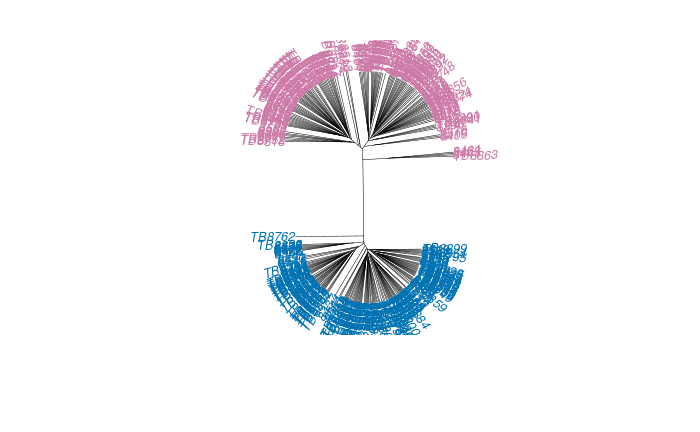

```r
sexLabel <- gsub("Female", "#CC79A7", sexLabel)
sexLabel <- gsub("Male", "#0072B2", sexLabel)

batchLabel <- palette(rainbow(10))[as.factor(metadata$batch)]
# cluster on XY probes - some mislabeled samples
plot(ape::as.phylo(hclust(dist(t(betasXY)))), lab4ut="axial", type = "unrooted", edge.width=0.5, cex=0.8, tip.color=sexLabel)
```

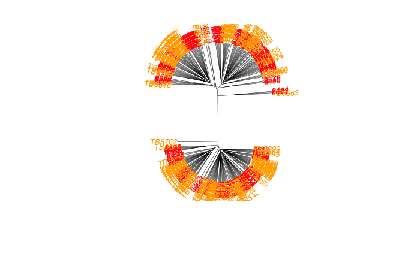

```r
plot(ape::as.phylo(hclust(dist(t(betasXY)))), lab4ut="axial", type = "unrooted", edge.width=0.5, cex=0.8, tip.color=batchLabel)
```

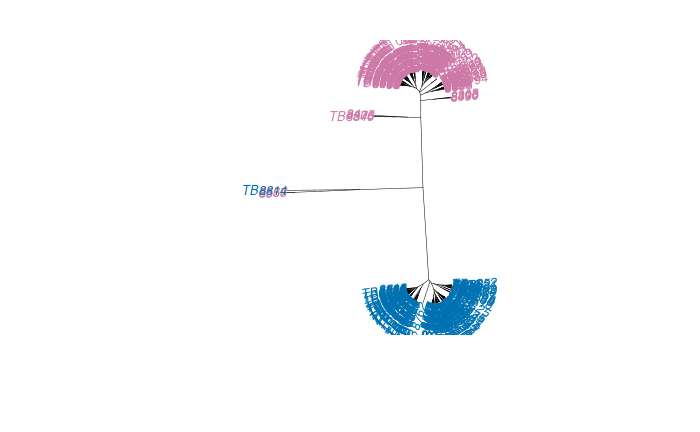

```r
# cluster on XIST probes - some mislabelled samples
plot(ape::as.phylo(hclust(dist(t(betasXIST)))), lab4ut="axial", type = "unrooted", edge.width=0.5, cex=0.8, tip.color=sexLabel)
```

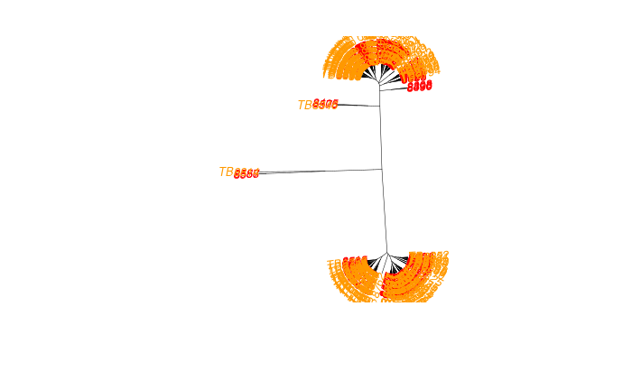

```r
plot(ape::as.phylo(hclust(dist(t(betasXIST)))), lab4ut="axial", type = "unrooted", edge.width=0.5, cex=0.8, tip.color=batchLabel)
```

```r
#just looking at batch
# plot(ape::as.phylo(hclust(dist(t(betas)))), lab4ut="axial", type = "unrooted", edge.width=0.5, cex=0.8, tip.color=batchLabel)
```

### Main QC

```r
qc <- getQC(mset)
head(qc)
```

```
DataFrame with 6 rows and 2 columns
          mMed      uMed
     <numeric> <numeric>
8366   12.2524   12.4165
8367   12.0272   12.3707
8368   12.1273   12.6711
8369   12.1889   12.5241
8370   12.0140   12.5653
8371   11.9629   12.5911
```

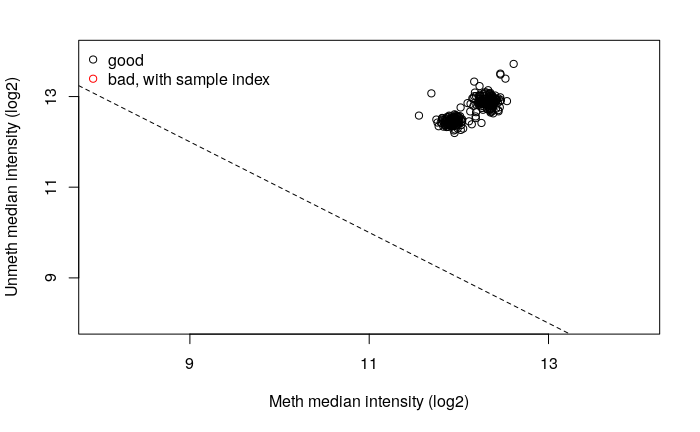

```r
plotQC(qc) # all samples are good quality (yay) none need to be removed
```

```r
# add QC to your metadata (can join pData and qc) if any samples look odd at this step, decide on a threshold for m,edian intensity to retain the majority of the samples.

mset_filt <- mset
betas <- getBeta(mset_filt)
```

```r
detP <- methy_data[,grepl("Detection Pval", colnames(methy_data))]
colnames(detP) <- gsub("\\..*","", colnames(detP))
head(detP)
```

|  | 8366 | 8367 | 8368 | 8369 | 8370 | 8371 | 8372 | 8374 | 8394 | 8395 | 8396 | 8397 | 8399 | 8400 | 8401 | 8403 | 8405 | 8407 | 8408 | 8409 | 8410 | 8418 | 8419 | 8420 | 8421 | 8422 | 8423 | 8424 | 8425 | … |
| --- | --- | --- | --- | --- | --- | --- | --- | --- | --- | --- | --- | --- | --- | --- | --- | --- | --- | --- | --- | --- | --- | --- | --- | --- | --- | --- | --- | --- | --- | --- |
| cg00000029 | 0 | 0 | 0 | 0 | 0 | 0 | 0 | 0 | 0 | 0 | 0 | 0 | 0 | 0 | 0 | 0 | 0 | 0 | 0 | 0 | 0 | 0 | 0 | 0 | 0 | 0 | 0 | 0 | 0 | … |
| cg00000108 | 0 | 0 | 0 | 0 | 0 | 0 | 0 | 0 | 0 | 0 | 0 | 0 | 0 | 0 | 0 | 0 | 0 | 0 | 0 | 0 | 0 | 0 | 0 | 0 | 0 | 0 | 0 | 0 | 0 | … |
| cg00000109 | 0 | 0 | 0 | 0 | 0 | 0 | 0 | 0 | 0 | 0 | 0 | 0 | 0 | 0 | 0 | 0 | 0 | 0 | 0 | 0 | 0 | 0 | 0 | 0 | 0 | 0 | 0 | 0 | 0 | … |
| cg00000165 | 0 | 0 | 0 | 0 | 0 | 0 | 0 | 0 | 0 | 0 | 0 | 0 | 0 | 0 | 0 | 0 | 0 | 0 | 0 | 0 | 0 | 0 | 0 | 0 | 0 | 0 | 0 | 0 | 0 | … |
| cg00000236 | 0 | 0 | 0 | 0 | 0 | 0 | 0 | 0 | 0 | 0 | 0 | 0 | 0 | 0 | 0 | 0 | 0 | 0 | 0 | 0 | 0 | 0 | 0 | 0 | 0 | 0 | 0 | 0 | 0 | … |
| cg00000289 | 0 | 0 | 0 | 0 | 0 | 0 | 0 | 0 | 0 | 0 | 0 | 0 | 0 | 0 | 0 | 0 | 0 | 0 | 0 | 0 | 0 | 0 | 0 | 0 | 0 | 0 | 0 | 0 | 0 | … |

```r
failed <- detP > 0.01
colMeans(failed) # average # failed probes per sample
```

[output not shown]

[output cut: 14 more lines]

```r
sum(rowMeans(failed)>0.2) # 323 failed probes (detP>0.01) in >20% samps
```

```
[1] 392
```

```r
failed <- rownames(detP[rowMeans(failed)>0.2,]) # vector of 350 failed probe IDs
head(failed)
```

```
[1] "cg00013655" "cg00035864" "cg00050873" "cg00061551" "cg00061679" "cg00063477"
```

```r
# remove detP failing probes
dim(betas) # 485512
```

```
[1] 485577    302
```

```r
betas <- betas[!(rownames(betas) %in% failed), ]
dim(betas) # 485189
```

```
[1] 485185    302
```

```r
naBeta<- is.na(betas)
naBeta <- print(sum(rowMeans(naBeta)>0.2)) # 79 missing betas in >20% samps
```

```
[1] 0
```

```r
# remove NA  probes
dim(betas) # 485189
```

```
[1] 485185    302
```

```r
betas <- betas[!(rownames(betas) %in% naBeta), ]
dim(betas) # 485110
```

```
[1] 485185    302
```

```r
# SNP probes - already gone (by preprocessNoob)
rs_probes <- grep(pattern = "^rs", x = rownames(betas)) # vector of rs rownames
length(rs_probes) # 0
```

```
[1] 65
```

```r
# XY probes
dim(betas) # 342762
```

```
[1] 485185    302
```

```r
betasXY <- betas[(rownames(betas) %in% rownames(sexProbeIDs)),]
dim(betasXY) # 9813 preprocessed X probes
```

```
[1] 11347   302
```

```r
betas <- betas[!(rownames(betas) %in% rownames(sexProbeIDs)) & !(rownames(betas) %in% rs_probes),]
dim(betas) # 332949 preprocessed autosomal probes
```

```
[1] 473838    302
```

#### Non-specific probes

Based on the work of Magda (Price), we know that several probes on the 450K and EPIC arrays are non-specific to their target locations in the genome, that is, based on sequencing similarity they have been predicted to bind to multiple locations in the genome and are therefore cross-hybridizing and/or nonspecific. These probes are therefore not reliable, as we don’t know which location in the genome they are actually reflecting the methylation patterns of, and we remove these probes prior to analysis.

```r
priceAnno <- read.csv("/arc/project/st-dennisjk-1/wcasazza/methylation_QC_resources/price_et_al_450k_annot.csv")
priceXY <- priceAnno[grepl("YES",priceAnno$XY_Hits),] #12388
priceAuto <- priceAnno[grepl("YES",priceAnno$Autosomal_Hits),] #40650

# remove these CH probes
dim(betas) # 485110
```

```
[1] 473838    302
```

```r
betas <- betas[!(rownames(betas) %in% priceXY$ID), ]
betas <- betas[!(rownames(betas) %in% priceAuto$ID), ]
dim(betas) # 443324
```

```
[1] 437244    302
```

#### Polymorphic

Probes with SNPs (>1% MAF) in the SBE site of the CpG of interest will be filtered using both Chen et al. 2013’s annotation for the array (from the Weksberg lab) and Kasper D. Hansen’s built in SNP data for the Illumina arrays. Information on Hansen’s data can be found in the package pdf for the Illumina manifest. These objects are named ‘SNPs.###CommonSingle’ with ### corresponding to the version of dbSNP for which the data was constructed, higher numbers represent later versions of dbSNP.

Chen et al. 2013: https://www.ncbi.nlm.nih.gov/pmc/articles/PMC3592906/

Chen annotation can be downloaded from the Weksberg lab website: http://www.sickkids.ca/Research/Weksberg-Lab/Publications/index.html * (this URL annoyingly sometimes changes, google Weksberg lab if you can’t locate it, usually under their “Publications” page)

Hansen: https://bioconductor.org/packages/release/data/annotation/manuals/IlluminaHumanMethylation450kanno.ilmn12.hg19/man/IlluminaHumanMethylation450kanno.ilmn12.hg19.pdf **NOTE** This will NOT be applied since we are interested in the association of SNP and DNA methylation.

```r
# read in chen polymoprhic probes
Chen <- readxl::read_xlsx("/arc/project/st-dennisjk-1/wcasazza/methylation_QC_resources/48640-polymorphic-CpGs-Illumina450k.xlsx")

# Polymorphic CpGs (including polymorphic SBE sites) correspond to entries where BASE_FROM_SBE is less than or equal to 1 for infinium II probes and less than or equal to 2 for infinium I probes.
str(Chen)
Chen$BASE_FROM_SBE <- as.factor(Chen$BASE_FROM_SBE)
levels(Chen$BASE_FROM_SBE) # 0, 1, and 2 probes are either polymorphic or have poly SBE

# check that none of the "BASE_FROM_SBE" values are >1 for tye II probes
ProbeII <- Chen[which(Chen$INFINIUM == "II"),]
dim(ProbeII) # 57536 rows
ProbeII$BASE_FROM_SBE <- factor(ProbeII$BASE_FROM_SBE)
levels(ProbeII$BASE_FROM_SBE) # 0 and 1

# select only those probes that have a MAF > 1%
dim(Chen) # 70889
Chen_SNP <- Chen[which(Chen$AF > 0.01),]
dim(Chen_SNP) # 14140

# remove all of the probes identified as polymorphic by Chen et al.
dim(betas) # 443324
betas <- betas[!(rownames(betas) %in% Chen_SNP$PROBE),]
dim(betas) # 431409
```

#### Subset mset to filtered probes

At this stage, subset your original mset to the list of filtered probes.

```r
# define list of filtered probes
probes_keep <- as.character(rownames(betas))

mset_filt <- mset[probes_keep, -c(76,89)]
dim(mset_filt)
```

```
[1] 424994    300
```

```r
all.equal(rownames(betas), rownames(mset_filt)) # should be TRUE
```

```
[1] TRUE
```

### Data Normalization

#### 4.2 Normalize mset objects

If I don’t have rgset objects available for use with minfi’s normalization functions, I would use one of these options. There are definitely other options out there (dasen for example) but tend to be more laborious to code, and are also used less frequently in the literature. Can check out if interested.

##### 4.2.1 minfi::Quantile

The minfi function for quantile normalization is applicable to both rgest and msets. For a description of this method, see Touleimat & Tost, 2012. *This function returns a GenomicRatioSet*. This method relies on a reference distribution of Type I probes that it normalizes the distribution of Type II probes against, so setting the seed is important to ensure the same random distribution of Type I reference probes is selected each time, for reproducible normalization.

https://www.rdocumentation.org/packages/minfi/versions/1.18.4/topics/preprocessQuantile

[figure not shown]

## Saving the “best” data

```r
write.table(metadata,"DNAm_w_paired_genotype_metadata.txt", row.names = F, quote=F,sep="\t")
fwrite(as.data.frame(betas.quantile) %>% rownames_to_column("cpg"),"processed_DNAm_delahaye_quantile_norm.txt", quote=F, row.names = F,sep="\t")
```